# И снова Shiny

Сегодня мы продолжим работу с Shiny.

- рассмотрим еще раз, как преобразовать готовый код в приложение
- посмотрим, как автоматически переносить данные (переменные, значения и т.д.) в интерфейс из датасета (а не перепечатывать вручную)
- поговорим об оптимальности и структуре программы

В качестве примера возьмем лабораторную про PCA (practice_8-2).

Сразу уберем из нее части, связанные с исследованием, т.е. те, где мы смотрим на данные, строим разведочный график, пробуем разные реализации одного и того же метода, выводим в консоль результаты и т.д. Используются данные о колледжах

```r
library(ISLR)
data <- College

set.seed(345)
data.test.ind = sample(seq_len(nrow(data)), size = nrow(data)*0.2)
data.test = data[data.test.ind,]
data.main = data[-data.test.ind,]

library(caret)
```

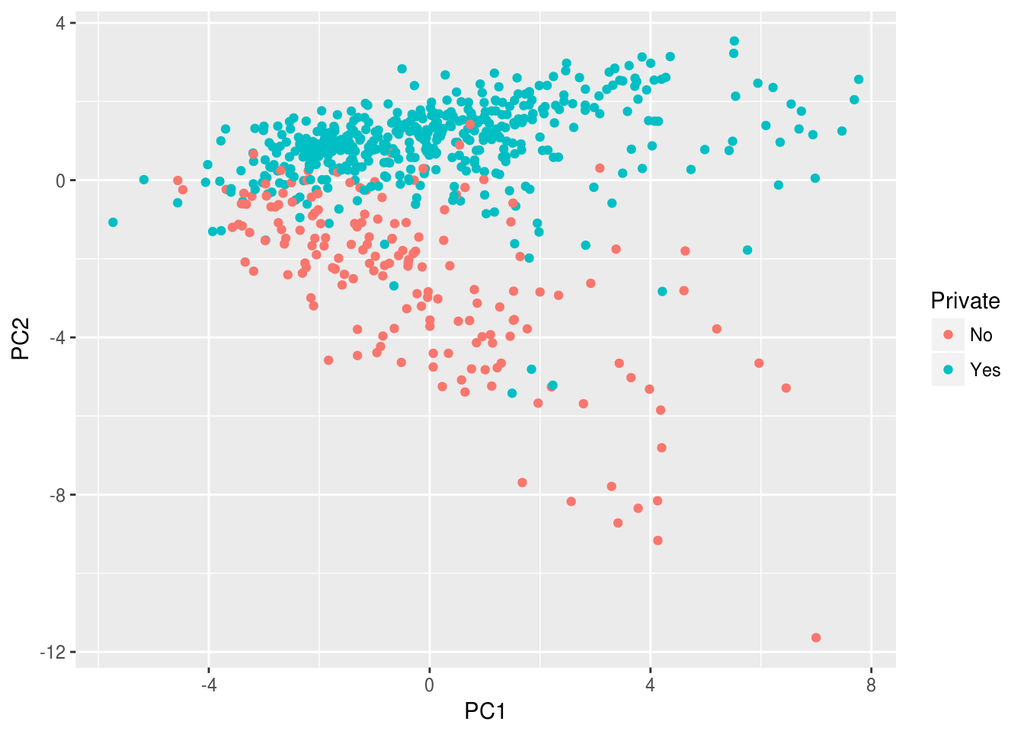

```r
preprocessParams <- preProcess(data.main, method=c("center", "scale", "pca"))

# трансформация данных
transformed.main <- predict(preprocessParams, data.main)
transformed.test <- predict(preprocessParams, data.test)

library(ggplot2)
ggplot() + geom_point(data = transformed.main, aes(x = PC1, y = PC2, color = Private))
```

```r
#модель
library(e1071)
svm_model <- svm(Private~., data = transformed.main)

#Результаты на обучающей
svm.PredMain<-predict(svm_model, transformed.main, probability=FALSE)
cmMain = confusionMatrix(svm.PredMain,transformed.main$Private)
cmMain$overall
```

```
##       Accuracy          Kappa  AccuracyLower  AccuracyUpper   AccuracyNull
##   9.598071e-01   8.955829e-01   9.412369e-01   9.738233e-01   7.250804e-01
## AccuracyPValue  McnemarPValue
##   1.327344e-53   3.182172e-04
```

```r
#и тестовой выборках
svm.PredTest<-predict(svm_model, transformed.test, probability=FALSE)
cmTest = confusionMatrix(svm.PredTest,transformed.test$Private)
cmTest$overall
```

```
##       Accuracy          Kappa  AccuracyLower  AccuracyUpper   AccuracyNull
##   9.290323e-01   8.101970e-01   8.765682e-01   9.640428e-01   7.354839e-01
## AccuracyPValue  McnemarPValue
##   7.385189e-10   2.278000e-01
```

```r
rbind(t(cmMain$overall), t(cmTest$overall))
```

```
##       Accuracy     Kappa AccuracyLower AccuracyUpper AccuracyNull
## [1,] 0.9598071 0.8955829     0.9412369     0.9738233    0.7250804
## [2,] 0.9290323 0.8101970     0.8765682     0.9640428    0.7354839
##      AccuracyPValue McnemarPValue
## [1,]   1.327344e-53  0.0003182172
## [2,]   7.385189e-10  0.2277999940
```

Теперь будем преобразовывать этот код в приложение.

1. **Что хотим:** приложение, которое строит svm модель для предсказания частный колледж или государственный (Private) с использованием метода PCA для преобразования переменных. В качестве результата – таблица с метриками на обучающей и тестовой выборке
2. **Что может менять пользователь:** значение set.seed + какие переменные использовать для предсказания

#### Начинаем…

Интерфейс:

- поле для ввода set.seed
- список для выбора переменных
- таблица с результатами на тестовой выборке и обучающей выборке

В этот раз данные используем и в интерфейсе тоже, поэтому определяем их **вне** функций:

```r
library(ISLR)
dataInitial <- College

ui <- fluidPage(
   titlePanel("Пример работы с PCA"),
   sidebarLayout(
      sidebarPanel(
         numericInput("seed",
                     "Установите set.seed",
                     min = 1,
                     value = 1325),
         selectInput("varnames",
                     "Выберите переменные для анализа",
                     choices = names(dataInitial)[-1],  #удаляем Private из списка выбора
                     multiple = TRUE)   # для выбора нескольких элементов списка

      ),
      mainPanel(
         tableOutput("metrics")
      )
   )
)
```

Сервер: нам нужна таблица

```r
server <- function(input, output) {

   output$metrics <- renderTable({ })
}
```

За создание собственно таблицы с результатами отвечает только последняя строка, поэтому ее вносим внутрь функции renderTable

```r
server <- function(input, output) {

   output$metrics <- renderTable({
     rbind(t(cmMain$overall), t(cmTest$overall))
   })
}
```

- А куда все остальное?

Просто вынести в начало функции server мы не можем – там есть элементы, которые меняются от действий пользователя. С другой стороны, к выводу таблиц с результатами эти действия тоже не особо относятся.

Для таких случаев существует функция reactive, которая реагирует на действия пользователя, но ничего не меняет в интерфейсе. Реакцию на разные действия лучше выносить в разные функции – так эффективнее

- hint: загрузите пакеты ДО функции, описывающей действия сервера

```r
server <- function(input, output) {

  selectedData <- reactive({
    #выбор переменных
  })

  trainTest = reactive({
    # разбиение обучающая-тестовая
  })

  transformation <- reactive({
    #преобразование данных
  })

   output$metrics <- renderTable({
     rbind(t(cmMain$overall), t(cmTest$overall))
   })
}
```

Реализуем эти функции

```r
server <- function(input, output) {
   dataSelected <- reactive({
     if (length(input$varnames)<2) dataInitial  # если выбрано меньше 2 предикторов
     else dplyr::select(dataInitial, c(input$varnames, "Private")) # выбираем переменные и добавляем Private к данным
  })

  trainTest = reactive({
    data = dataSelected()
    set.seed(input$seed)
    data.test.ind = sample(seq_len(nrow(data)), size = nrow(data)*0.2)
    data.test.ind
  })

  transformation <- reactive({
    data = dataSelected()
    data.test = data[trainTest(),]
    data.main = data[-trainTest(),]
    preprocessParams <- preProcess(data.main, method=c("center", "scale", "pca"))
    transformed.main <- predict(preprocessParams, data.main)
    transformed.test <- predict(preprocessParams, data.test)
    svm_model <- svm(Private~., data = transformed.main)
    #Результаты на обучающей
    svm.PredMain<-predict(svm_model, transformed.main, probability=FALSE)
    cmMain = confusionMatrix(svm.PredMain,transformed.main$Private)
    #и тестовой выборках
    svm.PredTest<-predict(svm_model, transformed.test, probability=FALSE)
    cmTest = confusionMatrix(svm.PredTest,transformed.test$Private)
    rbind(t(cmMain$overall), t(cmTest$overall))
  })

   output$metrics <- renderTable({
     transformation()
   })
}
```

**Ваша очередь:** Добавьте в PCA отбор количества признаков по порогу `thresh = ...`, задаваемому пользователем. Пример из лабораторной по PCA

```r
preprocessParams3 <- preProcess(dplyr::select(data.main, -Private),
                                method=c("center", "scale", "pca"), thresh = 0.8)
```

#### Использование ранее преобразованных данных

А если мы не хотим разрешать пользователю менять параметры данных? Тогда все преобразования лучше сделать заранее, сохранить результат с помощью save(), а затем просто использовать

Например, мы хотим попробовать разные алгоритмы классификации, но выполнять их на одинаково преобразованных данных после PCA. Т.е. нам нужны только `transformed.main` и `transformed.test`. И не важно, как мы их получили

```r
save(transformed.main, transformed.test, file = "pca.Rdata")
```

Переносим файл в папку с новым приложением. Загрузить объекты можно с помощью load()

```r
server <- function(input, output) {

  load("pca.Rdata")

   output$metrics <- renderTable({
     #построение моделей
   })

}
```

**Ваша очередь:** Реализуйте вычисления для разных алгоритмов классификации

- hint: разные команды для разного выбора методов можно реализовать с помощью switch()